# How to combine data from Open Tree of Life and GBIF

Emily Jane McTavish

2022-05-04

For background complete the introductory tutorials on rgbif and on rotl to familiarize yourself.  
https://ropensci.org/tutorials/rotl_tutorial/  
https://ropensci.org/tutorials/rgbif_tutorial/

# Combining evolutionary and geographic information

In order to examine geographic distributions of species, it is useful to tie together information about phylogenetic relationships, which we can get from Open Tree of Life, with information about where individuals of that species are found.

```r
install.packages(c("httr", "jsonlite", "rgbif", "rotl", "phytools", "viridis"))
library(httr)
library(jsonlite)
library(rgbif)
library(rotl)
library(phytools)
library(viridis)
```

# Choose some species

Lets look for some fun species, A polar bear, “Ursus maritimus”, a hippo “Hippopotamus amphibius”, a gorilla “Gorilla gorilla” and a wild boar “Sus scrofa”.

```r
polarbear <-"Ursus maritimus"
hippo <-"Hippopotamus amphibius"
boar <-"Sus scrofa"
gorilla <- "Gorilla gorilla"
dolphin <- "Tursiops truncatus"

spp <- c(polarbear, boar, gorilla, hippo,dolphin)
```

We can use Open Tree of Life to generate a tree for our species!

[figure not shown]

```r
taxa <- rotl::tnrs_match_names(spp, context="Animals")
tr <-  rotl::tol_induced_subtree(ott_id(taxa), label="name")
```

```
##
Progress [----------------------------------] 0/62 (  0%) ?s
Progress [================================] 62/62 (100%)  0s
```

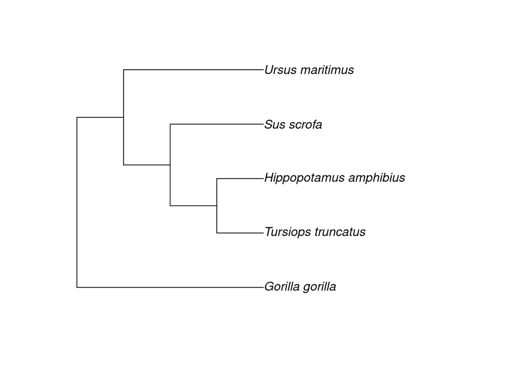

```r
plot(tr)
```

# Don’t forget to cite the studies that went into building your tree!

Pulling supporting studies isn’t included in rotl yet (or I couldn’t find it). So we will use an Open Tree API call directly.

```r
url_ot <- 'https://api.opentreeoflife.org/v3/tree_of_life/induced_subtree'
body <- list(ott_ids=taxa$ott_id)
r <- httr::POST(url_ot, body = body, encode = "json")#gets which studies support the subtree from  the open tree API
for(studytree in httr::content(r)$supporting_studies){
study <-  strsplit(studytree, '@')[[1]][1]
meta <- get_study_meta(study) #pulls the metadata for each study
pub <- get_publication(meta)  #grabs teh publication information
cat(pub,"\n\n")
}
```

```
## Lartillot, Nicolas, Frédéric Delsuc. 2012. Joint reconstruction of divergence times and life-history evolution in placental mammals using a phylogenetic covariance model. Evolution 66 (6): 1773-1787.
##
## O'Leary, M. A., J. I. Bloch, J. J. Flynn, T. J. Gaudin, A. Giallombardo, N. P. Giannini, S. L. Goldberg, B. P. Kraatz, Z.-X. Luo, J. Meng, X. Ni, M. J. Novacek, F. A. Perini, Z. S. Randall, G. W. Rougier, E. J. Sargis, M. T. Silcox, N. B. Simmons, M. Spaulding, P. M. Velazco, M. Weksler, J. R. Wi…
##
## Springer, Mark S., Robert W. Meredith, John Gatesy, Christopher A. Emerling, Jong Park, Daniel L. Rabosky, Tanja Stadler, Cynthia Steiner, Oliver A. Ryder, Jan E. Janečka, Colleen A. Fisher, William J. Murphy. 2012. Macroevolutionary dynamics and historical biogeography of primate diversification…
##
## Mark S. Springer, Christopher A. Emerling, Robert W. Meredith, Jan E. Janečka, Eduardo Eizirik, William J. Murphy, 2017, 'Waking the undead: Implications of a soft explosive model for the timing of placental mammal diversification', Molecular Phylogenetics and Evolution, vol. 106, pp. 86-102
##
## Meredith, R.W., Janecka J., Gatesy J., Ryder O.A., Fisher C., Teeling E., Goodbla A., Eizirik E., Simao T., Stadler T., Rabosky D., Honeycutt R., Flynn J., Ingram C., Steiner C., Williams T., Robinson T., Herrick A., Westerman M., Ayoub N., Springer M., & Murphy W. 2011. Impacts of the Cretaceous…
##
## Tarver, J. E., P. C. J. Donoghue, M. J. Benton. 2011. Is evolutionary history repeatedly rewritten in light of new fossil discoveries? Proceedings of the Royal Society B: Biological Sciences 278 (1705): 599-604.
##
## Graham J. Slater, Jeremy A. Goldbogen, Nicholas D. Pyenson, 2017, 'Independent evolution of baleen whale gigantism linked to Plio-Pleistocene ocean dynamics', Proceedings of the Royal Society B: Biological Sciences, vol. 284, no. 1855, p. 20170546
##
## Perelman, P., Johnson W.E., Roos C., Seuánez H.N., Horvath J.E., Moreira M.A., Kessing B.D., Pontius J., Roelke M., Rumpler Y., Schneider M.C., Silva A., O'brien S., & Pecon-slattery J. 2011. A Molecular Phylogeny of Living Primates. PLoS Genetics 7(3): e1001342.
##
## Nyakatura, Katrin, Olaf RP Bininda-Emonds. 2012. Updating the evolutionary history of Carnivora (Mammalia): a new species-level supertree complete with divergence time estimates. BMC Biology 10 (1): 12
##
## Krause, Johannes, Tina Unger, Aline Noçon, Anna-Sapfo Malaspinas, Sergios-Orestis Kolokotronis, Mathias Stiller, Leopoldo Soibelzon, Helen Spriggs, Paul H Dear, Adrian W Briggs, Sarah CE Bray, Stephen J O'Brien, Gernot Rabeder, Paul Matheus, Alan Cooper, Montgomery Slatkin, Svante Pääbo, Michael …
##
## Toljagi&#263; O., Voje K.L., Matschiner M., Liow L., & Hansen T.F. 2017. Millions of Years Behind: Slow Adaptation of Ruminants to Grasslands. Systematic Biology, .
##
## Steeman, M., Hebsgaard M., Fordyce R., Ho S., Rabosky D., Nielsen R., Rahbek C., Glenner H., Sørensen M., & Willerslev E. 2009. Radiation of Extant Cetaceans Driven by Restructuring of the Oceans. Systematic Biology 58 (6): 573-585.
##
## McGowen, M., Spaulding M., and Gatesy J. 2009. Divergence date estimation and a comprehensive molecular tree of extant cetaceans. Molecular Phylogenetics and Evolution 53 (3): 891-906.
```

# Lets combine the phylogenetic information from Open Tree with geographic information from GBIF

```r
dat1 <- rgbif::occ_search(scientificName = polarbear, fields=c('name','decimalLatitude', 'decimalLongitude'), limit = 10)
locsdat1 <- cbind(polarbear, dat1$data) #labels the lat long columns with the species name
colnames(locsdat1)<-c("species","Long","Lat")

dat2 <- rgbif::occ_search(scientificName = hippo, fields=c('name','decimalLatitude', 'decimalLongitude'), limit = 10)
locsdat2 <- cbind(hippo, dat2$data)
colnames(locsdat2)<-c("species","Long","Lat")

dat3 <- rgbif::occ_search(scientificName = boar,  fields=c('name','decimalLatitude', 'decimalLongitude'), limit = 10)
locsdat3 <- cbind(boar, dat3$data)
colnames(locsdat3)<-c("species","Long","Lat")

dat4 <- rgbif::occ_search(scientificName = gorilla, fields=c('name','decimalLatitude', 'decimalLongitude'), limit = 10)
locsdat4 <- cbind(gorilla, dat4$data)
colnames(locsdat4)<-c("species","Long","Lat")

dat5 <- rgbif::occ_search(scientificName = dolphin, fields=c('name','decimalLatitude', 'decimalLongitude'), limit = 10)
locsdat5 <- cbind(dolphin, dat5$data)
colnames(locsdat5)<-c("species","Long","Lat")

locs <- as.data.frame(rbind(locsdat1,locsdat2, locsdat3, locsdat4, locsdat5)) #Combine the data from each species
locs
```

```
##                   species        Long        Lat
## 1         Ursus maritimus  -93.816720  58.733208
## 2         Ursus maritimus  -94.152214  58.775311
## 3         Ursus maritimus -156.858589  71.226550
## 4         Ursus maritimus   12.389055  78.930327
## 5         Ursus maritimus  -93.959003  58.766739
## 6         Ursus maritimus -156.723045  71.350298
## 7         Ursus maritimus  -93.192528  58.649208
## 8         Ursus maritimus  -20.507641  74.428475
## 9         Ursus maritimus -156.670606  71.272698
## 10        Ursus maritimus  -94.104818  58.765814
## 11 Hippopotamus amphibius   37.315509  -2.705606
## 12 Hippopotamus amphibius   27.055363 -25.321550
## 13 Hippopotamus amphibius   32.461800 -28.284100
## 14 Hippopotamus amphibius   19.834524 -34.665625
```

[output cut: 36 more lines]

```r
locs[,1] <- gsub(' ','_',locs[,1])#On the tree, names have underscores instead of spaces.
#Sometimes the lat longs have spaces in the records.
#We use trimws to get rid of the whitespace, and as.numeric to record the the latitudes and longitudes as numbers instead of characters.
locs[,2]<-as.numeric(trimws(as.character(locs[,2])))
locs[,3]<-as.numeric(trimws(as.character(locs[,3])))
latlong <- as.matrix(locs[,c(3,2)]) #flip the columns to lat, long instead of long,lat
rownames(latlong) <- locs[,1]
```

Check that your species are all included and have the correct names (taxonomic name recognition sometimes updates them)

```r
latlong
```

```
##                               Lat        Long
## Ursus_maritimus         58.733208  -93.816720
## Ursus_maritimus         58.775311  -94.152214
## Ursus_maritimus         71.226550 -156.858589
## Ursus_maritimus         78.930327   12.389055
## Ursus_maritimus         58.766739  -93.959003
## Ursus_maritimus         71.350298 -156.723045
## Ursus_maritimus         58.649208  -93.192528
## Ursus_maritimus         74.428475  -20.507641
## Ursus_maritimus         71.272698 -156.670606
## Ursus_maritimus         58.765814  -94.104818
## Hippopotamus_amphibius  -2.705606   37.315509
## Hippopotamus_amphibius -25.321550   27.055363
## Hippopotamus_amphibius -28.284100   32.461800
## Hippopotamus_amphibius -34.665625   19.834524
## Hippopotamus_amphibius -28.133800   32.529800
## Hippopotamus_amphibius  -2.822808   38.021624
## Hippopotamus_amphibius -28.236500   32.408200
## Hippopotamus_amphibius  -3.399534   39.191352
## Hippopotamus_amphibius -28.133000   32.528700
## Hippopotamus_amphibius -28.134200   32.530200
## Sus_scrofa              50.869137    6.425629
## Sus_scrofa              49.988293    8.907829
## Sus_scrofa              49.979488    8.509169
## Sus_scrofa              50.410290    8.210533
## Sus_scrofa              50.132347    8.952374
## Sus_scrofa              49.976768    8.567899
## Sus_scrofa              52.178852    9.147406
## Sus_scrofa              48.920700   10.269532
## Sus_scrofa              49.976425    9.723029
## Sus_scrofa              50.326050    7.982176
## Gorilla_gorilla         -1.600545   12.972422
## Gorilla_gorilla         -0.317679   11.667805
## Gorilla_gorilla         -2.998760   10.053514
## Gorilla_gorilla         -1.605592   12.868204
## Gorilla_gorilla         -1.624496   13.163600
## Gorilla_gorilla         -1.651610   12.849542
## Gorilla_gorilla         35.078382 -106.663485
## Gorilla_gorilla         -1.721151   12.894200
## Gorilla_gorilla         -1.738712   12.884102
## Gorilla_gorilla         -1.711025   12.930430
## Tursiops_truncatus      25.008885 -110.689321
## Tursiops_truncatus      33.811742 -118.392640
## Tursiops_truncatus      34.057997 -119.614499
## Tursiops_truncatus      27.940834  -97.164837
## Tursiops_truncatus     -46.565697  168.418270
## Tursiops_truncatus      33.715199 -118.255547
## Tursiops_truncatus      29.812679  -85.314767
## Tursiops_truncatus      27.751821  -97.392456
## Tursiops_truncatus      27.982494  -97.066288
## Tursiops_truncatus      43.452470    4.045470
```

# Now to join together the geographic information with the phylogenetic information!

Trees from OpenTree don’t automatically come with branch lengths - we need to infer some branch lengths for this tree in order to plot it. (in future we can use R-Datelife! datelife.org)

```r
tr_bl<-ape::compute.brlen(tr)
```

Combine the phylogeny and the mapped locations

```r
cols<-setNames(sample(viridis(n=ape::Ntip(tr_bl))),
    tr_bl$tip.label)# This sets the colors to pretty colors
tdobj<-phytools::phylo.to.map(tr_bl,latlong,plot = FALSE, direction="rightwards")
```

```
## objective: 4
## objective: 4
## objective: 4
```

```
## objective: 2
```

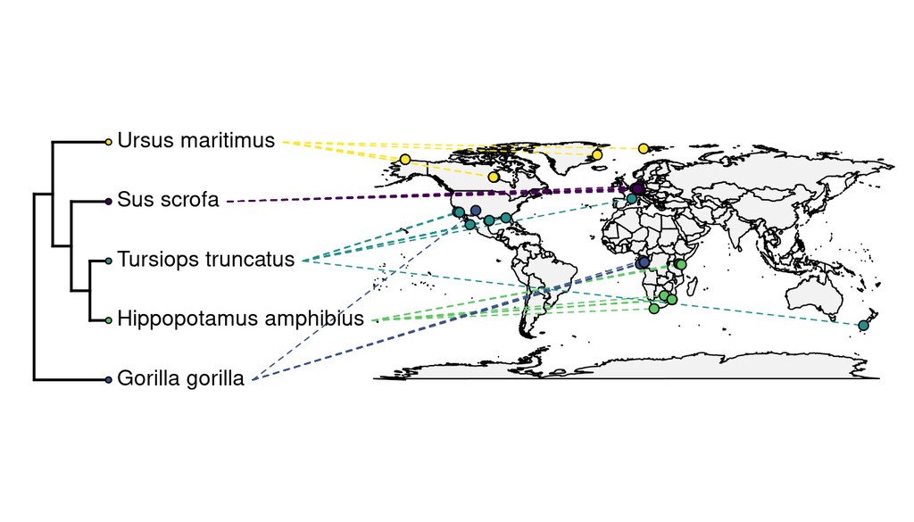

```r
plot(tdobj, colors=cols, direction="rightwards")
```

```r
#If there is an error with 'cols' try this instead:
#plot(tdobj, direction="rightwards")
```

# We can do a better job of name matching by actually using the cross taxonomy mappings already encoded in the Open Tree Taxonomy!

Lets try some plants

```r
spp2 <- c("Mimulous guttatus","Arabidopsis thaliana", "Musa gracilis", "Carex capitata")
taxa2 <- rotl::tnrs_match_names(spp2)
tr2 <- rotl::tol_induced_subtree(ott_id(taxa2), label="name")
```

```
##
Progress [---------------------------------] 0/100 (  0%) ?s
Progress [==============================] 100/100 (100%)  0s
```

```r
tr_bl2<-ape::compute.brlen(tr2)
taxa2[,"gbif"] <- NA
locs = data.frame(matrix(vector(), nrow(taxa2), 2))
i=1
for(id in taxa2$ott_id){
   tax_info <- rotl::taxonomy_taxon_info(id)
   for(source in tax_info[[1]]$tax_sources){
     if (grepl('gbif', source, fixed=TRUE)){
            gbif_id <- strsplit(source,":")[[1]][2]
            taxa2[i,]$gbif <-gbif_id
            result <- rgbif::occ_search(taxonKey = gbif_id, fields=c('name','decimalLatitude', 'decimalLongitude'), limit = 5)
            if (dim(result$data)[1] > 0) {
                try(locs[i,1] <- as.data.frame(result$data)[2])
                try(locs[i,2] <- as.data.frame(result$data)[1])
            }
     }}
   i = i + 1}
rownames(locs) <- gsub(' ','_',taxa2$unique_name)
colnames(locs) <- c("latitude","longitude")
```

One of our species got reconciled to a synonym!

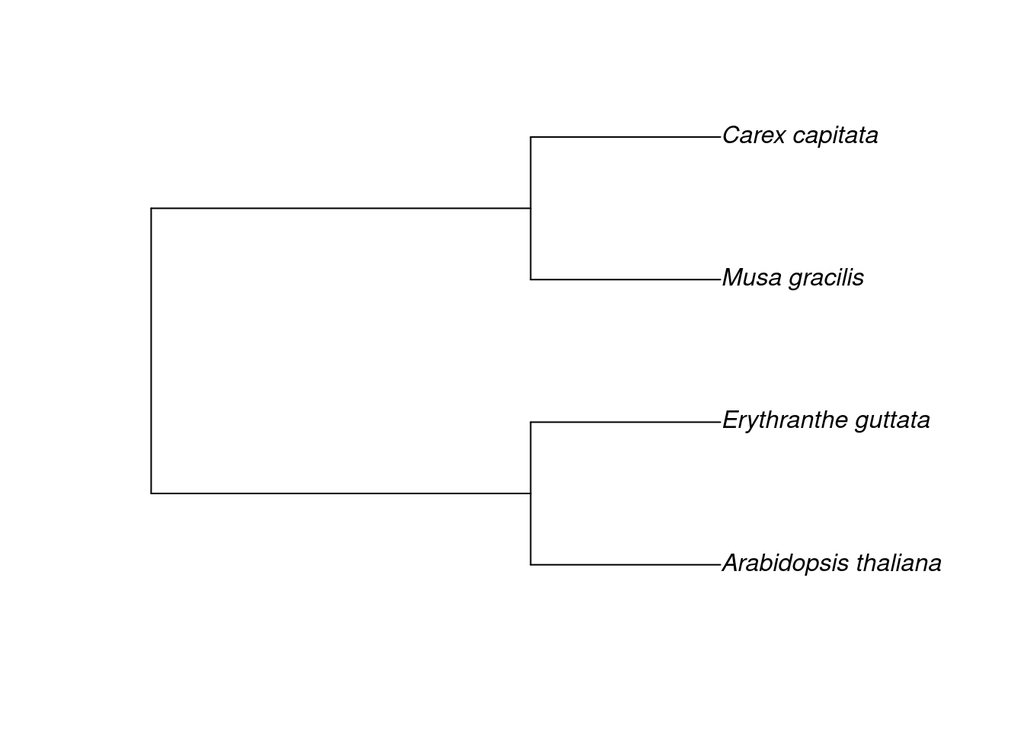

```r
plot(tr2)
```

```r
taxa2
```

```
##          search_string          unique_name approximate_match ott_id is_synonym
## 1    mimulous guttatus  Erythranthe guttata              TRUE 504496      FALSE
## 2 arabidopsis thaliana Arabidopsis thaliana             FALSE 309263      FALSE
## 3        musa gracilis        Musa gracilis             FALSE   8478      FALSE
## 4       carex capitata       Carex capitata             FALSE   4161      FALSE
##            flags number_matches    gbif
## 1                             5 7346102
## 2                             1 3052436
## 3 sibling_higher              1 2762973
## 4 sibling_higher              1 2728838
```

Because we are mapping tips based on keys instead of names, the name replacement doesn’t matter affect our mapping

```r
tdobj2<-phytools::phylo.to.map(tr_bl2,locs, plot = FALSE, direction="rightwards")
```

```
## objective: 4
```

```
## objective: 2
## objective: 2
```

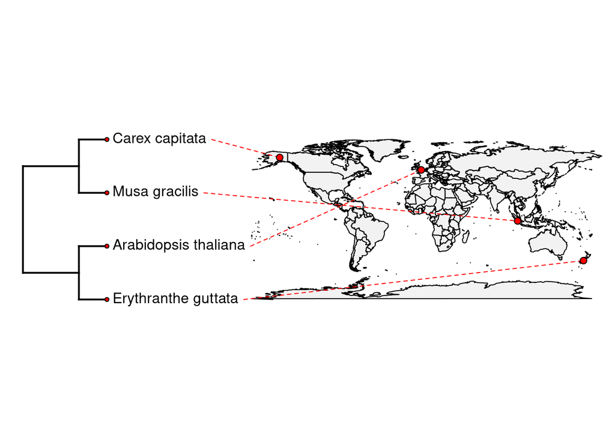

```r
plot(tdobj2, direction="rightwards")
```